# Plant pathogens drive density‐dependent seedling mortality in a tropical tree - Bell - 2006 - Ecology Letters - Wiley Online Library

[Ecology Letters](https://onlinelibrary.wiley.com/journal/14610248)

[Volume 9, Issue 5](https://onlinelibrary.wiley.com/toc/14610248/2006/9/5) p. 569-574

[figure not shown]

Full Access

# Plant pathogens drive density-dependent seedling mortality in a tropical tree

[Thomas Bell](https://onlinelibrary.wiley.com/action/doSearch?ContribAuthorStored=Bell%2C+Thomas),

[Robert P. Freckleton](https://onlinelibrary.wiley.com/action/doSearch?ContribAuthorStored=Freckleton%2C+Robert+P),

[Owen T. Lewis](https://onlinelibrary.wiley.com/action/doSearch?ContribAuthorStored=Lewis%2C+Owen+T),

First published: 14 March 2006

https://doi.org/10.1111/j.1461-0248.2006.00905.x

Citations: 341

## Introduction

A single hectare of humid tropical forest can support over 300 tree species (Valencia *et al.* 1994), but the processes that allow so many species to coexist remain unclear (Givnish 1999; Wright 2002). One possibility is that density-dependent mortality puts locally rare species at an advantage, preventing any one species from reaching high abundance (Janzen 1970; Connell 1971; Harms *et al.* 2000). Recent studies have provided strong evidence that density-dependent processes play a role in the maintenance of plant diversity in the tropics (Gilbert *et al.* 1994; Wills *et al.* 1997; Wills & Condit 1999; Harms *et al.* 2000; Peters 2003), and more widely (Lambers *et al.* 2002; Lambers & Clark 2003), and that the seed-to-seedling transition is a critical stage in determining the diversity of plants in larger size classes (Harms *et al.* 2000; Lambers *et al.* 2002; Connell *et al.* 2005; Wright *et al.* 2005). The precise causes of density dependence remain less certain.

Density-dependent mortality and growth can be generated by intraspecific competition and by the action of specialized natural enemies (herbivores and pathogens). Observational studies are consistent with the hypothesis that natural enemies drive density dependence, with seeds and seedlings thought to occur at insufficiently high abundance for competition to generate the patterns observed (Wright 2002). Insect herbivores and seed predators, mammal herbivores and plant pathogens have all been suggested as possible causes of density dependence, but data confirming their role are lacking. Pathogens, particularly fungus-like oomycetes which cause ‘damping off’ disease in small seedlings, have long been suspected as agents of density-dependent mortality in tropical forests (Augspurger 1984; Augspurger & Kelly 1984; Augspurger & Kitajima 1992; Dalling *et al.* 1998; Gilbert 2002; Hood *et al.* 2004; Gilbert 2005), and there is growing evidence for density-dependent effects of plant pathogens in temperate ecosystems (e.g. Klironomos 2002; Packer & Clay 2000; Reinhart *et al.* 2003). However, the impact of plant pathogens may have been underestimated or misrepresented in previous observational studies where confounding effects cannot be excluded. For example, resource competition at high densities may make individuals more prone to attack by pathogens, so pathogens may be a symptom rather than a cause of density dependence (Burdon 1982; Dobson & Crawley 1994). In contrast, experimental manipulations of both density and pathogen levels offer an unambiguous demonstration of the underlying interactions.

Here, we describe a manipulative field experiment in moist tropical forest in Belize, Central America, which demonstrates a key role for plant pathogens in inflicting density-dependent mortality of newly germinated seedlings. We simultaneously conducted an observational study on the same system and show how the observational approach would have underestimated or failed to identify the nature of the interaction between density and pathogen-induced mortality.

## Materials and methods

### Study site

The field site was in moist tropical forest near the Las Cuevas Research Station in the 170 000 ha Chiquibul Forest Reserve, Cayo District, in south-west Belize. This forest is classified as deciduous seasonal forest and deciduous/semi-evergreen seasonal forest (Wright *et al.* 1959). The climate is seasonal, with a humid season typically from June to January and a dry season from February to May. The Chiquibul Forest is affected by hurricanes, and much of the vegetation in the study area has grown up following extensive wind and fire damage resulting from Hurricane Hattie in 1961.

### Fungal exclusion experiment

We treated plots containing germinating seedlings of a locally common neotropical tree, *Sebastiana longicuspis* Standl. (Euphorbiaceae), with a selective fungicide, Ridomil Gold® (Syngenta Ltd, Basel, Switzerland). This metalaxyl-based, sytemic fungicide is targeted at fungus-like pathogens in the Oomycota including species of *Phytophthora* and *Pythium* which cause damping-off diseases in young seedlings (Cohen & Coffey 1986). This fungicide has low toxicity to organisms other than fungi, and has been found to have minimal inhibitory effects on arbuscular mycorrhizae in agricultural systems (e.g. Afek *et al.* 1990; Seymour *et al.* 1994). The experiment comprised six 1 m<sup>2</sup> blocks, each divided into four 25 × 25-cm plots. The location of each block was selected to maximize the number of newly germinated (cotyledon stage) *S. longicuspis* seedlings. All blocks were within 5 m of each other, and were immediately below a cluster of mature *S. longicuspis* trees.

Density (high or low) and fungicide (sprayed or control) were allocated at random to each plot, so each of the four treatment combinations was represented once in each block. In low-density plots, we manipulated the initial density of seedlings to 25 per plot (100 individuals m<sup>−2</sup>) by hand thinning. In high-density treatments, we left seedling density unmanipulated; seedling density in these plots ranged from 416 to 1068 individuals m<sup>−2</sup>. Fungicide was applied using a hand-held mister at the manufacturer's recommended concentration of 0.25 g m<sup>−2</sup>, with 50 mL of solution applied to each 0.0625-m<sup>2</sup> plot. Control plots were treated with an identical volume of water. The fungicide treatment was applied weekly from 3 June to 8 July 2005. At the initial census, each seedling was labelled individually. Newly germinating seedlings were counted and marked each week, and the number of seedling fatalities recorded.

The proportion of seedlings dying over the course of the experiment was analysed using a generalized linear model in which block, density, fungicide and the interaction between density and fungicide were entered as fixed factors, assuming a binomial error distribution and logit-link function. The initial model exhibited overdispersion (dispersion coefficient = 1.95). We found that inclusion of a block × fungicide term reduced the over-dispersion to an acceptable level (dispersion coefficient = 0.90).

## Results

### Fungal exclusion experiment

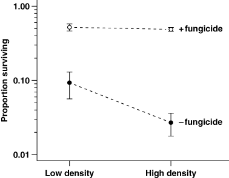

**Figure 1**

Proportion of *Sebastiana longicuspis* surviving in an experiment that manipulated seedling density and fungal pathogens. Each data point is the mean of six replicates, and the error bars show standard errors.

### Observational survey

In the non-manipulative survey there was a significant overall effect of density (*F* = 7.16, d.f. = 4,182, *P* < 0.0001). However, examination of the model coefficients for the individual weekly surveys indicated that only the first survey yielded a strong relationship between density and pathogen infection (*t* = 4.53, d.f. = 182, *P* < 0.0001), with the third yielding a weaker relationship (*t* = 2.44, d.f. = 182, *P* < 0.05) and the other two no significant relationship (*t* = 1.54, d.f. = 182, *P* = NS; *t* = 1.24, d.f. = 182, *P* = n.s.) (Fig. 2).

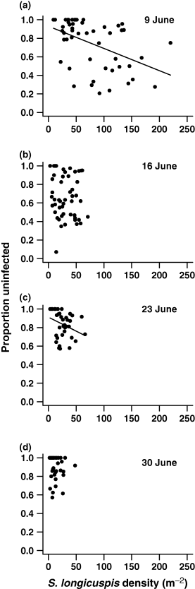

**Figure 2**

Relationship between the proportion of *Sebastiana longicuspis* seedlings uninfected by fungal pathogens and the density of seedlings, censused at weekly intervals. Each data point is a census from a 1-m<sup>2</sup> quadrat.

## Discussion

Our results demonstrate that fungal pathogens inflict severe mortality on young seedlings of *S. longicuspis*, and that this mortality is clearly density dependent. The experiment is unique in manipulating both plant pathogen abundance and seedling density *in situ* in a tropical forest, and provides direct evidence for the role of plant pathogens as agents of density-dependent mortality in this species. The approach that we have used – simultaneous experimental manipulation of both pathogens and density in the field – may be useful in determining the role of pathogens in the dynamics of tree populations and communities elsewhere in the tropics, and also in temperate ecosystems where plant pathogens may have a large but cryptic influence on the diversity and structure of ecological communities (e.g. Van der Putten *et al.* 1993; Klironomos 2002; Packer & Clay 2000; Reinhart *et al.* 2003).

Previous studies of pathogen infection in relation to plant density in tropical forests have found mixed results (Augspurger 1983, 1984; Augspurger & Kelly 1984; Augspurger & Kitajima 1992; Gilbert *et al.* 1994; Gilbert 2002, 2005). For example, density of *Platypodium elegans* seedlings in Panama affected rates of infection by a damping-off pathogen, but there was a complex interaction with distance from parent tree, and variable results among trees (Augspurger & Kelly 1984), making the role of density in this species unclear. As our data demonstrate, it is the interaction with pathogen incidence that is of importance, and only manipulative experiments can fully reveal the nature of this interaction. For example, our observational study provided at best an uncertain picture of the influence of seedling density on survival. In large part this was because high mortality in high-density patches resulted in the relationship between density and infection weakening through time (Fig. 2), as seedling densities were thinned rapidly to a level at which further mortality from pathogens was minimal.

Density-dependent mortality affecting seeds and small seedlings may have been overlooked in most previous plot-based studies in tropical forests, which focus on plants in larger size categories (Harms *et al.* 2000). We now need to identify how widespread such effects are across a diverse set of tropical and temperate tree species. The hypothesis that density-dependent mortality generates the latitudinal gradient in plant species richness requires that tropical forests experience more intense or more widespread density-dependent mortality that temperate forests (Lambers *et al.* 2002), and it seems unlikely that this issue will be resolved until there have been experimental manipulations quantifying the strength of density-dependent mortality using several species in both temperate and tropical ecosystems.

An important but unknown factor is the degree of host specificity of the pathogens causing mortality in *S. longicuspis* and other tropical trees (Jarosz & Davelos 1995). Density dependence is only expected to have a strong diversity-enhancing role when pathogens show high specificity (Janzen 1970; Connell 1971). *Pythium* species known from agricultural systems typically have low host specificity, while *Phytophthora* can be more specialized (Augspurger 1990); but data from tropical forest environments are lacking. Molecular and experimental approaches will now be required to measure the specificity of pathogen species and strains isolated from seedlings of individual tropical tree species, and to disentangle the correlated effects of seedling density and distance from mature conspecific and heterospecific trees (Augspurger 1990; Hood *et al.* 2004). Oomycete pathogens typically have steep dispersal curves, so that their incidence is highly heterogeneous over small spatial scales (Augspurger 1990). Host-specific oomycete pathogens may build up high inoculum levels in the soil around parent trees through the input of susceptible seeds and seedlings whereas they typically exist at low density or heterogeneously in the soil further from conspecifics (Packer & Clay 2000, 2003).

Pathogen host specificity will also be of interest in the context of wider community composition. If pathogens are oligophagous at higher taxonomic levels, for example, infecting confamilial plant species (Gentry 1988), density-mediated indirect effects such as apparent competition (Holt 1977; Connell 1990; Holah & Alexander 1999) among plant taxa may structure these communities. For example, pathogen-mediated indirect effects may reduce the likelihood that trees from the same family (which are more likely to share pathogens) recruit in close proximity. In a recent study of sapling mortality on Barro Colorado Island, Panama, 11 of 60 species showed reduced growth in proximity to confamilial and congeneric species (Uriarte *et al.* 2004). It remains to be determined whether a similar or more pronounced trend occurs in small seedlings, whether mortality as well as growth is affected, and whether shared pathogens are driving such effects.

If intense density-dependent pathogen-induced mortality of seedlings is widespread, plant pathogens may play a key role in maintaining and structuring tropical diversity. However, it will be important to understand the degree to which seed and seedling dynamics translate into differences in adult tree composition. This is likely to be influenced by longer-term interactions among larger seedlings and saplings, and on the outcome of competition for gaps (Denslow 1987). Long-term plot-based studies are thus required to confirm whether ecological processes involving small seedlings operating under a closed canopy determine the template for the next generation of mature trees (e.g. Connell *et al.* 2005).

## Acknowledgements

This study was funded by the UK Natural Environment Research Council (Grant NE/C515063/1) with research permission from the Ministry for Natural Resources, Government of Belize. We thank Augustine Howe and the staff of the Las Cuevas Research Station for assistance with fieldwork, Greg Gilbert, Sarah Gurr and Allen Herre for advice on pathogen biology, and the anonymous referees for their helpful comments. OTL and RPF are Royal Society University Research Fellows.

## Citing Literature

[Volume9, Issue5](https://onlinelibrary.wiley.com/toc/14610248/2006/9/5)

May 2006

Pages 569-574

### Metrics

Citations: 341